# SCFA report - Demo dataset 1

Author

Microbiome Insights

Published

November 14, 2025

# Summary of SCFA data (SCFA concentration)

This study evaluates Plasma SCFA measurements for project Demo dataset 1. Short-chain fatty acids were quantified using GC-FID and normalized to SCFA concentration.

## Summarised Statistics

| SCFA | Group | Time | Samples | Subjects | Mean | SD | SEM | Min | Max |
| --- | --- | --- | --- | --- | --- | --- | --- | --- | --- |
| Acetic.Acid | A | T0 | 10 | 10 | 5.09 | 0.36 | 0.11 | 4.69 | 5.89 |
| Acetic.Acid | B | T0 | 10 | 10 | 8.01 | 0.38 | 0.12 | 7.37 | 8.44 |
| Propionic.Acid | A | T0 | 10 | 10 | 2.81 | 0.45 | 0.14 | 2.16 | 3.61 |
| Propionic.Acid | B | T0 | 10 | 10 | 3.15 | 0.46 | 0.14 | 2.65 | 4.08 |
| Butyric.Acid | A | T0 | 10 | 10 | 2.04 | 0.62 | 0.20 | 1.02 | 2.86 |
| Butyric.Acid | B | T0 | 10 | 10 | 2.11 | 0.44 | 0.14 | 1.23 | 2.68 |

# SCFA concentrations

Box-and-whisker plots display the data for each acid. Analysis of variance (ANOVA) was performed to assess statistical differences among variables, followed by Tukey’s HSD pairwise comparisons.

## Visualization

**Acetic.Acid**

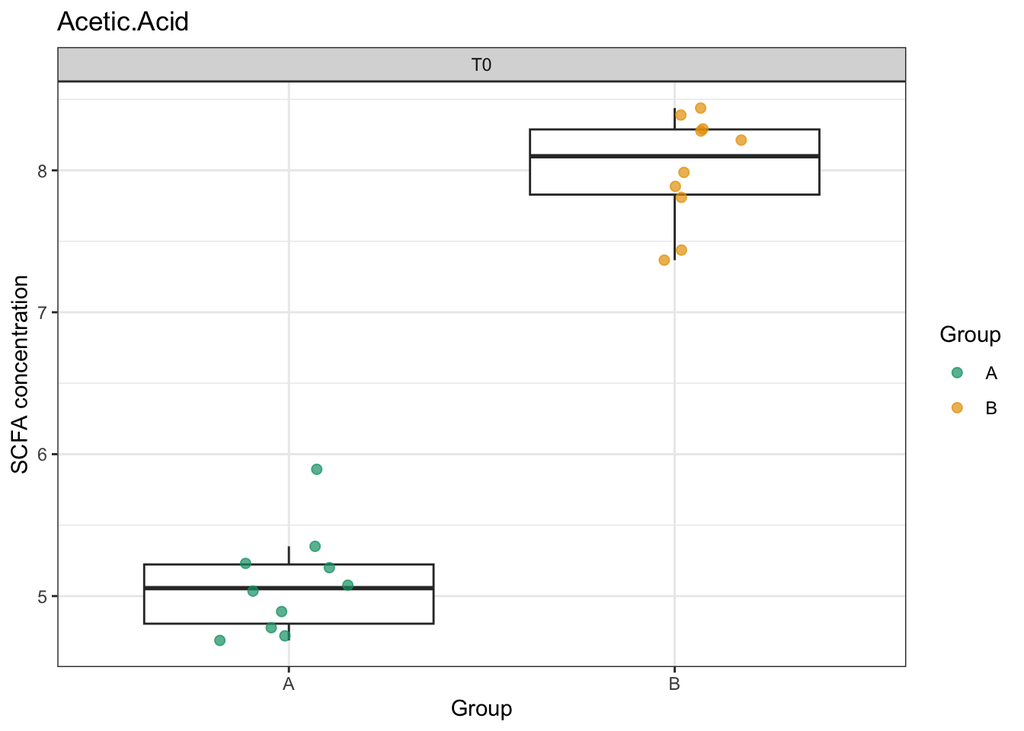

### Propionic.Acid

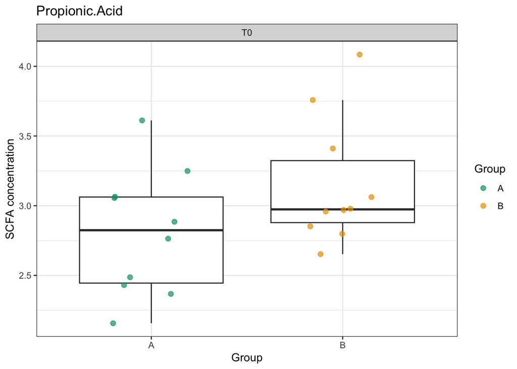

### Butyric.Acid

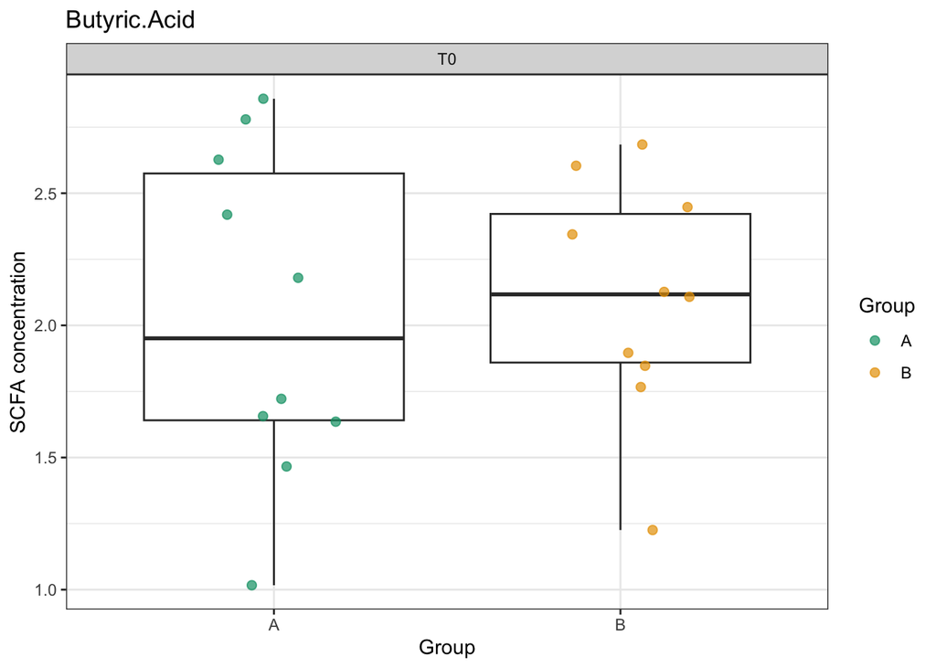